# Mimic-Fasting Diet Plan

Sandra Kilpatrick & Kate Ergle

September 09, 2015

# 1 Introduction

The diet is called the “Mimic Fasting Diet” -> http://www.telegraph.co.uk/news/science/science-news/11683736/Five-day-fasting-diet-slows-down-ageing-and-may-add-years-to-life.html.

Apparently, fasting has a lot of benefits. In addition to losing weight, fasting can slow the aging process and reduce the risk of some age-related diseases like cancer and diabetes.

So this is the structure of the diet plan: Reduce calorie intake for five days each month and eat food that is comprised of:

**Day 1 :: 1090 calories**

- Protein - 10% of the calories
- Fat - 56% calories
- Carbs - 34% calories

**Days 2 - 5 :: 725 calories**

- Protein - 9%
- Fat - 44%
- Carbs - 47%

Data source is the USDA Nutrition database from the USDA web site http://ndb.nal.usda.gov/ndb/doc/index.

Names of the columns and the descriptions of the columns are listed here: http://www.ars.usda.gov/sp2UserFiles/Place/80400525/Data/SR27/sr27_doc.pdf

# 2 Get all the data sets

## 2.1 Food group

This file is a support file to the Food Description file and contains a list of food groups used in SR27 and their descriptions.

The whole data frame:

```
##    FdGrp_Cd                          FdGrp_Desc
## 1       100              Dairy and Egg Products
## 2       200                    Spices and Herbs
## 3       300                          Baby Foods
## 4       400                       Fats and Oils
## 5       500                    Poultry Products
## 6       600          Soups, Sauces, and Gravies
## 7       700         Sausages and Luncheon Meats
## 8       800                   Breakfast Cereals
## 9       900             Fruits and Fruit Juices
## 10     1000                       Pork Products
## 11     1100   Vegetables and Vegetable Products
## 12     1200               Nut and Seed Products
## 13     1300                       Beef Products
## 14     1400                           Beverages
## 15     1500      Finfish and Shellfish Products
## 16     1600         Legumes and Legume Products
## 17     1700       Lamb, Veal, and Game Products
## 18     1800                      Baked Products
## 19     1900                              Sweets
## 20     2000             Cereal Grains and Pasta
## 21     2100                          Fast Foods
## 22     2200     Meals, Entrees, and Side Dishes
## 23     2500                              Snacks
## 24     3500 American Indian/Alaska Native Foods
## 25     3600                    Restaurant Foods
```

There are **25** entries in the food group data set.

**Column descriptions**

*FdGrp_Cd* : 4-digit code identifying a food group. Only the first 2 digits are currently assigned. In the future, the last 2 digits may be used.  
*FdGrp_Desc* : Name of food group.

**Class of each column**

```
## $FdGrp_Cd
## [1] "integer"
##
## $FdGrp_Desc
## [1] "character"
```

The following groups we don’t need for this project:

```
## [1] "Baby Foods"
## [2] "Fast Foods"
## [3] "American Indian/Alaska Native Foods"
## [4] "Restaurant Foods"
```

So we remove them from the data set.

## 2.2 Food

This file contains long and short descriptions and food group designators for all food items, along with common names, manufacturer name, scientific name, percentage and description of refuse, and factors used for calculating protein and kilocalories, if applicable. Items used in the FNDDS are also identified by value of “Y” in the Survey field.

```
##   NDB_No FdGrp_Cd                  Long_Desc                Shrt_Desc ManufacName
## 1   1001      100             Butter, salted         BUTTER,WITH SALT        <NA>
## 2   1002      100 Butter, whipped, with salt BUTTER,WHIPPED,WITH SALT        <NA>
## 3   1003      100      Butter oil, anhydrous     BUTTER OIL,ANHYDROUS        <NA>
## 4   1004      100               Cheese, blue              CHEESE,BLUE        <NA>
## 5   1005      100              Cheese, brick             CHEESE,BRICK        <NA>
## 6   1006      100               Cheese, brie              CHEESE,BRIE        <NA>
```

**Column descriptions**

*NDB_No* : 5-digit Nutrient Databank number that uniquely identifies a food item. If this field is defined as numeric, the leading zero will be lost.  
*FdGrp_Cd* : 4-digit code indicating food group to which a food item belongs.  
*Long_Desc* : 200-character description of food item.  
*Shrt_Desc* : 60-character abbreviated description of food item. Generated from the 200-character description using abbreviations in Appendix A. If short description is longer than 60 characters, additional abbreviations are made.

There are **8,618** rows in the data set.

**Pay attention!!!** The following **4** entries in the **Shrt_Desc** that are doubles:

```
##                                                      Shrt_Desc
## 1                                         BABYFOOD,MEAT,BF,STR
## 2 BEEF,CHUCK,UNDER BLADE CNTR STEAK,BNLESS,DENVER CUT,LN,0" FA
## 3     OIL,INDUSTRIAL,PALM KERNEL (HYDROGENATED),CONFECTION FAT
## 4                                     POPCORN,OIL-POPPED,LOFAT
```

So it is recommended to use the long descriptions in the future. In addition they are better for the undestanding.

**Class of each column**

```
## $NDB_No
## [1] "integer"
##
## $FdGrp_Cd
## [1] "integer"
##
## $Long_Desc
## [1] "character"
##
## $Shrt_Desc
## [1] "character"
##
## $ManufacName
## [1] "character"
```

Look at the foods (Long_Desc column) to understand what is there in this data set.

```
##                                                                                     Long_Desc
## 1                           Grapes, canned, thompson seedless, water pack, solids and liquids
## 2                     Spinach, frozen, chopped or leaf, cooked, boiled, drained, without salt
## 3                                              Beans, black, mature seeds, canned, low sodium
## 4                                     KEEBLER, FUDGE SHOPPE, Fudge Stripes, Holiday/Spiderman
## 5                                                      BUTCHER BOY MEATS, INC., Turkey Franks
## 6                                           KELLOGG'S, EGGO, Mini Muffin Tops, Chocolate Chip
## 7                                     Cranberry, low bush or lingenberry, raw (Alaska Native)
## 8                                                             Crackers, rye, wafers, seasoned
## 9                                                 Game meat, elk, ground, cooked, pan-broiled
## 10 Infant formula, MEAD JOHNSON, ENFAMIL, ENFACARE LIPIL, with iron, powder, with ARA and DHA
## 11                                             Sausage, chicken, beef, pork, skinless, smoked
## 12                                                                       PACE, Red Taco Sauce
## 13                        GEORGE WESTON BAKERIES, Brownberry Sage and Onion Stuffing Mix, dry
## 14                                                 Beets, pickled, canned, solids and liquids
## 15                                                       Fast foods, cookies, animal crackers
## 16                                            Cocoa mix, NESTLE, Rich Chocolate Hot Cocoa Mix
## 17                                                            Puddings, vanilla, ready-to-eat
## 18                    Pork, cured, ham, boneless, low sodium, extra lean and regular, roasted
## 19                                                Tomato products, canned, sauce, with onions
## 20                                               Fast foods, fish sandwich, with tartar sauce
```

### 2.2.1 Reduce the food data set

Originally there are **8,618** rows in the food data set.

Remove the foods that are from the 4 food groups that are not necessary for this project and were removed earlier from the food group data set. After this procedure there are **7,612** rows in the food data set.

## 2.3 Nutrient definition

This file is a support file to the Nutrient Data file. It provides the 3-digit nutrient code, unit of measure, INFOODS tagname, and description.

```
##   Nutr_No Units                    NutrDesc
## 1     203     g                     Protein
## 2     204     g           Total lipid (fat)
## 3     205     g Carbohydrate, by difference
## 4     207     g                         Ash
## 5     208  kcal                      Energy
## 6     209     g                      Starch
```

There are **150** entries in the nutrient definition data set.

**Column descriptions**

*Nutr_No* : Unique 3-digit identifier code for a nutrient.  
*Units* : Units of measure (mg, g and so on).  
*NutrDesc* : Name of nutrient/food component.

**Class of each column**

```
## $Nutr_No
## [1] "integer"
##
## $Units
## [1] "character"
##
## $NutrDesc
## [1] "character"
```

Actually only the following nutrients are needed for this project:

```
##   Nutr_No Units                    NutrDesc
## 1     203     g                     Protein
## 2     204     g           Total lipid (fat)
## 3     205     g Carbohydrate, by difference
## 4     208  kcal                      Energy
```

## 2.4 Nutrient

This file contains the nutrient values and information about the values, including expanded statistical information.

A nutrient is anything that nourishes a living being. We humans get our nutrients from what we eat, plants get theirs from the soil. While the best nutrients are natural, we can also get them from vitamins in a bottle. Organic nutrients consist of carbohydrates, fats, proteins.  
*Source: en.wikipedia.org/wiki/Nutrient*

```
##   NDB_No Nutr_No Nutr_Val
## 1   1001     203     0.85
## 2   1001     204    81.11
## 3   1001     205     0.06
## 4   1001     207     2.11
## 5   1001     208   717.00
## 6   1001     221     0.00
```

There are **654,572** entries in the nutrient data set.

**Column descriptions**

*NDB_No* : 5-digit Nutrient Databank number that uniquely identifies a food item.  
*Nutr_No* : Unique 3-digit identifier code for a nutrient.  
*Nutr_Val* : Amount in 100 grams, edible portion.

There are **150** unique nutrient values in the data set. Which should be the same as the number of entries in the nutrient definition data set.

**Class of each column**

```
## $NDB_No
## [1] "integer"
##
## $Nutr_No
## [1] "integer"
##
## $Nutr_Val
## [1] "numeric"
```

### 2.4.1 Reduce the size of nutrient data set

By limiting the **nutrients** data set to the only for this project necessary nutrients (Carbs, fat, protein and calories) the number of entries in the nutrient data set has been decreased to **34,472**. This smaller nutrient data set will make the join easier.

**Summary**

```
##      NDB_No         Nutr_No         Nutr_Val
##  Min.   : 1001   Min.   :203.0   Min.   :  0.00
##  1st Qu.: 8695   1st Qu.:203.8   1st Qu.:  2.90
##  Median :14273   Median :204.5   Median : 14.19
##  Mean   :15468   Mean   :205.0   Mean   : 67.61
##  3rd Qu.:20051   3rd Qu.:205.8   3rd Qu.: 63.30
##  Max.   :93600   Max.   :208.0   Max.   :902.00
```

We can notice that the nutrient value is very skewed. Let’s look at the histogram. For better visualisation the x axis has been limited.

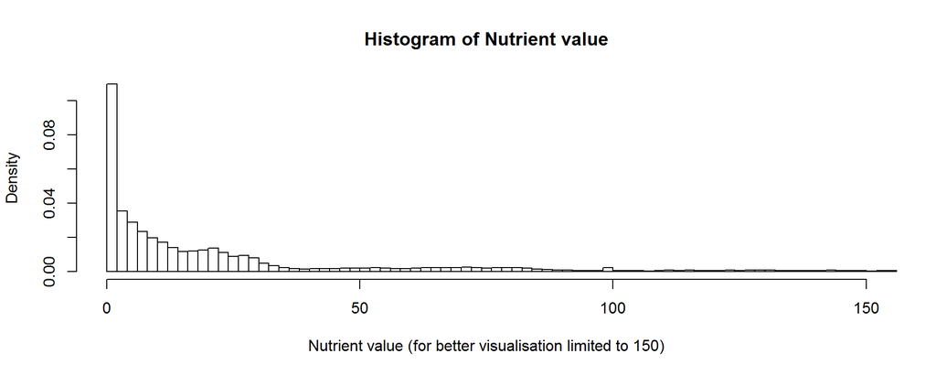

Even thought the maximum value is **902** for the nutrient value, there are **70%** data between **0** and **40**.

### 2.4.2 Reshape the data set

After reshaping the nutrient data set so that there would be only one row per food (per NDB_No), there are **8618** rows in the nutrient data set which should be the same as the number of rows in the food data set.

The head of the new nutrient data set:

```
##   NDB_No protein   fat carbohydrate energy
## 1   1001    0.85 81.11         0.06    717
## 2   1002    0.85 81.11         0.06    717
## 3   1003    0.28 99.48         0.00    876
## 4   1004   21.40 28.74         2.34    353
## 5   1005   23.24 29.68         2.79    371
## 6   1006   20.75 27.68         0.45    334
```

## 2.5 Weight

This file contains the weight in grams of a number of common measures for each food item.

```
##   NDB_No Seq Amount              Msre_Desc Gm_Wgt
## 1   1001   1      1 pat (1" sq, 1/3" high)    5.0
## 2   1001   2      1                   tbsp   14.2
## 3   1001   3      1                    cup  227.0
## 4   1001   4      1                  stick  113.0
## 5   1002   1      1 pat (1" sq, 1/3" high)    3.8
## 6   1002   2      1                   tbsp    9.4
```

There are **15,228** entries in the weight data set. And there are **1,917** unique entries int he measure description (Msre_Desc) column.

**Column descriptions**

*NDB_No* : 5-digit Nutrient Databank number.  
*Seq* : Sequence number.  
*Amount* : Unit modifier (for example, 1 in “1 cup”).  
*Msre_Desc* : Description (for example, cup, diced, and 1-inch pieces).  
*Gm_Wgt* : Gram weight.

**Class of each column**

```
## $NDB_No
## [1] "integer"
##
## $Seq
## [1] "integer"
##
## $Amount
## [1] "numeric"
##
## $Msre_Desc
## [1] "character"
##
## $Gm_Wgt
## [1] "numeric"
```

#### 2.5.0.1 Understand the **Seq** (sequence number) column

Frequency of each sequence number:

```
##
##    1    2    3    4    5    6    7    8    9   10   11   12   13   14   15   16
## 8373 4802 1110  424  243  140   63   31   17   11    6    3    2    1    1    1
```

Entries who have the sequence number 12:

```
##   NDB_No Seq Amount               Msre_Desc Gm_Wgt
## 1  11529  12      1       slice, thin/small     15
## 2  18255  12      1      honeybun (4" x 3")     65
## 3  19106  12      1 jelly ring (1-1/4" dia)     10
```

Let’s choose one of the foods (specific NDB_No) and look at it in the weight data set:

```
##    NDB_No Seq Amount                       Msre_Desc Gm_Wgt
## 1   11529   1      1             cup cherry tomatoes    149
## 2   11529   2      1          cup, chopped or sliced    180
## 3   11529   3      1                  Italian tomato     62
## 4   11529   4      1                          cherry     17
## 5   11529   5      1            large whole (3" dia)    182
## 6   11529   6      1       medium whole (2-3/5" dia)    123
## 7   11529   7      1      slice, medium (1/4" thick)     20
## 8   11529   8      1                     plum tomato     62
## 9   11529   9      1        small whole (2-2/5" dia)     91
## 10  11529  10      1 slice, thick/large (1/2" thick)     27
## 11  11529  11      1    wedge (1/4 of medium tomato)     31
## 12  11529  12      1               slice, thin/small     15
## 13  11529  13      1                    NLEA serving    148
```

Let’s look at the description of that food in the food data set:

```
##   NDB_No FdGrp_Cd                                    Long_Desc                              Shrt_Desc ManufacName
## 1  11529     1100 Tomatoes, red, ripe, raw, year round average TOMATOES,RED,RIPE,RAW,YEAR RND AVERAGE        <NA>
```

**Conclusion**: NDB_No and Seq together make the ID for this weight data set.

# 3 Join the data sets

All the data sets together:

```
##     data_set number_of_rows
## 1       food          7,612
## 2 food_group             21
## 3   nutrient          8,618
## 4     weight         15,228
```

After joining all the data sets the final data set has **13,688** rows.

**13,581** (out from the orginal **15,228**) entries in the weight data set are matched to the food data set. The rest of the entries were not matched because part of the food entries have been removed as they are not relevant for this project.

In addition there are more entries in the new joined data frame than in the matched weight data set because there are some foods (NDB_No) who don’t have an entry in the weight data set. There are **107** such foods.

## 3.1 Explore the missing foods in the weight data set

Amount per food group where the missing weights come from:

```
##                           FdGrp_Desc No_foods
## 1  Vegetables and Vegetable Products       47
## 2            Cereal Grains and Pasta       14
## 3            Fruits and Fruit Juices       10
## 4      Lamb, Veal, and Game Products        8
## 5                             Sweets        8
## 6         Soups, Sauces, and Gravies        6
## 7                  Breakfast Cereals        4
## 8                      Beef Products        3
## 9        Legumes and Legume Products        3
## 10                    Baked Products        2
## 11                         Beverages        1
## 12                            Snacks        1
```

All the foods listed where weights are missing:

```
##                                                                                                   Long_Desc
## 1                                                         USDA Commodity, spaghetti sauce, meatless, canned
## 2                                                                                     USDA Commodity, salsa
## 3                                                     Sauce, white, thin, prepared-from-recipe, with butter
## 4                                                               Sauce, sweet and sour, prepared-from-recipe
## 5                                                                              Sauce, cheese sauce mix, dry
## 6                                                                                   Sauce, alfredo mix, dry
## 7                         Cereals, QUAKER, Oat Bran, QUAKER/MOTHER'S Oat Bran, prepared with water, no salt
## 8                            Cereals, Oat Bran, QUAKER, QUAKER/MOTHER'S Oat Bran, prepared with water, salt
## 9                                  Cereals, QUAKER, QUAKER MultiGrain Oatmeal, prepared with water, no salt
## 10                                    Cereals, QUAKER, QUAKER MultiGrain Oatmeal, prepared with water, salt
## 11                                                                    Custard-apple, (bullock's-heart), raw
## 12                                                                                              Jujube, raw
## 13                                                                                            Jujube, dried
## 14                                                                                         Rose-apples, raw
```

[output cut: 93 more lines]

# 4 Explore the food + nutrient data set

As the data set with with added weights duplicate the food entries, we first look at the data set where only food, food_group and nutrient data sets are joined. This data set has the same number of entries as the food data set.

## 4.1 Number of foods per food group

```
##                           FdGrp_Desc No_foods
## 1                      Beef Products      946
## 2  Vegetables and Vegetable Products      828
## 3                     Baked Products      797
## 4         Soups, Sauces, and Gravies      452
## 5      Lamb, Veal, and Game Products      438
## 6                   Poultry Products      390
## 7        Legumes and Legume Products      389
## 8                  Breakfast Cereals      363
## 9                             Sweets      347
## 10           Fruits and Fruit Juices      346
## 11                     Pork Products      343
## 12                         Beverages      315
## 13    Finfish and Shellfish Products      267
## 14            Dairy and Egg Products      264
## 15       Sausages and Luncheon Meats      244
## 16                     Fats and Oils      219
## 17           Cereal Grains and Pasta      183
## 18                            Snacks      171
## 19             Nut and Seed Products      133
## 20   Meals, Entrees, and Side Dishes      113
## 21                  Spices and Herbs       64
```

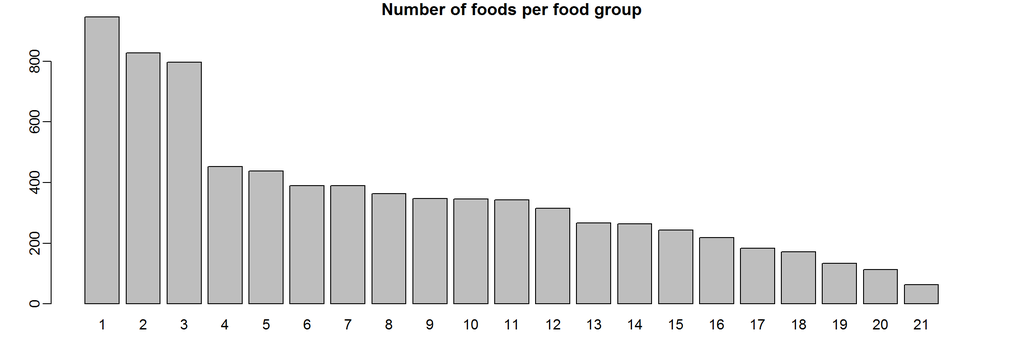

## 4.2 Nutrient distribution per nutrient

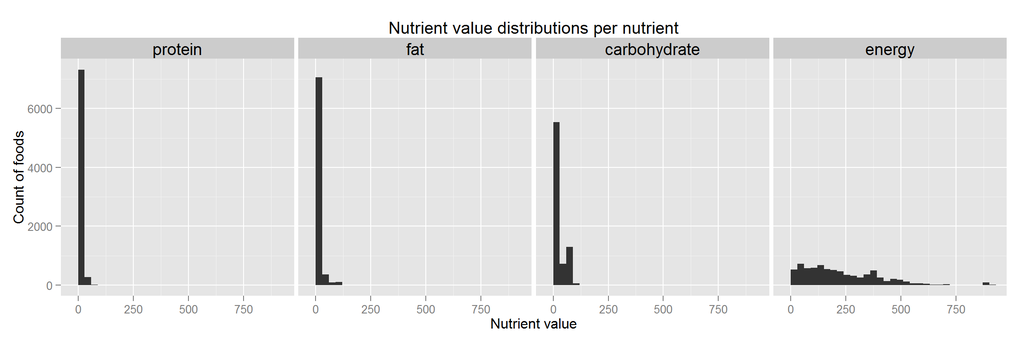

## 4.3 Protein, fat and carbohydrate distributions per food group

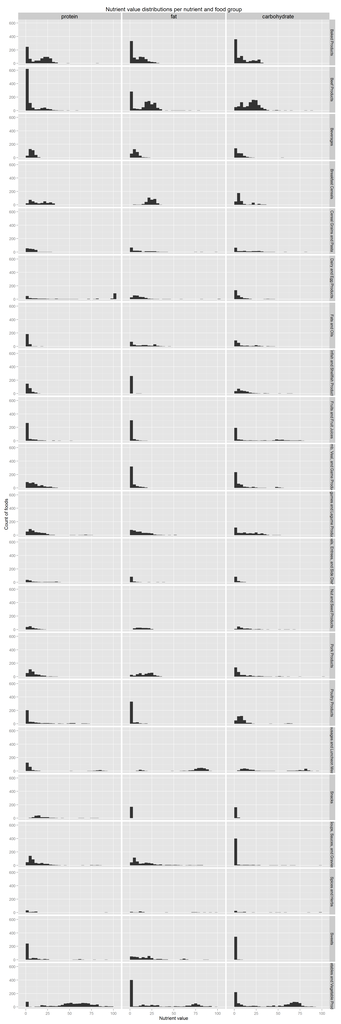

## 4.4 Energy (calories) distribution per food group

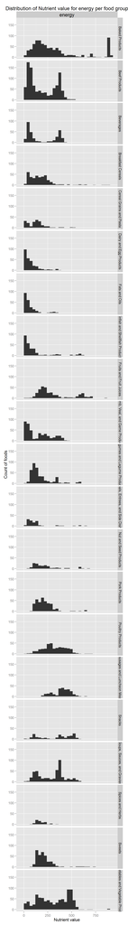